# Analisis Perbedaan antara Film Rating G dengan Rating R pada Database Sakila

Muhammad Syifaaul Munaa (M0725082)

# Pendahuluan

[figure not shown]

## Latar Belakang

Database Sakila adalah database contoh (sample database) resmi yang disediakan oleh MySQL. Database ini dirancang khusus untuk merepresentasikan model bisnis nyata di era pra-digital, yaitu jaringan toko rental film (DVD/VCD fisik) skala global. Database ini memiliki 16 tabel utama yang saling berelasi. Pada Analisis ini, saya menggunakan tabel **film**. Saya mengambil beberapa atribut dari tabel **film**, yaitu *title, length, rental_rate,* dan *rental_duration* yang lalu saya bandingkan dengan rating R dan G.

Dalam operasional bisnis penyewaan DVD fisik seperti Sakila, toko rental fisik sangat bergantung pada ketersediaan fisik kaset di rak toko. Oleh karena itu, keuntungan bisnis sangat dipengaruhi oleh tiga variabel utama, yaitu: **Durasi Film (`length`)**, **Tarif Sewa (`rental_rate`)**, dan **Batas Waktu Peminjaman (`rental_duration`)** yang dibandingkan dengan rating R dan G. Kedua rating ini mencerminkan strategi segmentasi pasar yang sangat berbeda nyata:

**Rating G (Semua Umur):** Ditujukan untuk pasar keluarga dan anak-anak. Secara industri, film kelompok ini diproduksi dengan struktur narasi yang linier, sederhana, universal, dan fokus pada hiburan ringan yang mudah dicerna dalam waktu singkat.

**Rating R (Dewasa/Terbatas):** Ditujukan khusus untuk pemirsa dewasa karena memuat konten yang intens, mendalam, atau kompleks. Narasi yang berat pada film rating R secara teoretis membutuhkan eksplorasi cerita yang lebih panjang dan dramatis.

Hubungan ketiga variabel ini menciptakan sebuah ekosistem keputusan bisnis yang saling mengikat:

1. **Durasi Film (`length`) sebagai Indikator Konsumsi Waktu:** Secara psikologis dan praktis, film dengan durasi yang panjang membutuhkan komitmen waktu tonton yang lebih besar dari pelanggan. Hal ini berpotensi memengaruhi seberapa cepat pelanggan dapat menyelesaikan tontonan mereka dan mengembalikan kaset tersebut ke toko.
2. **Batas Waktu Peminjaman (`rental_duration`) sebagai Pengendali Perputaran Stok:** Untuk mengantisipasi pengembalian kaset di tangan pelanggan, manajemen menetapkan batasan hari pinjam (`rental_duration`). Jika sebuah film memiliki durasi yang panjang namun batas waktu peminjamannya terlalu singkat, hal ini dapat menurunkan kepuasan pelanggan. Sebaliknya, jika batas waktu terlalu longgar, perputaran stok kaset di toko akan melambat (*low inventory turnover*), yang berarti toko kehilangan potensi pendapatan dari calon penyewa berikutnya.
3. **Tarif Sewa (`rental_rate`) sebagai Kompensasi Finansial & Penyeimbang Risiko:** Manajemen ritel harus menentukan harga sewa yang adil dan strategis. Film dengan durasi panjang yang memiliki perputaran lebih lama di luar toko idealnya dikompensasikan dengan tarif sewa (`rental_rate`) yang optimal. Tarif sewa harus mampu mencerminkan nilai hiburan yang didapatkan pelanggan sekaligus.

Melalui analisis statistika komparatif ini, kita tidak hanya sekadar melihat angka terisolasi, melainkan menguji apakah manajemen Sakila selama ini telah menetapkan kebijakan keuangan (`rental_rate`) dan kebijakan operasional (`rental_duration`) yang sinkron dan proporsional berdasarkan karakteristik fisik durasi film (`length`) yang disewakan. Pemahaman terhadap pola hubungan ketiga variabel ini akan memberikan **insight**krusial bagi manajemen untuk merancang ulang strategi dan regulasi peminjaman yang lebih efisien dan memaksimalkan profitabilitas toko, Khususnya pada film dengan rating R dan G.

## Rumusan Masalah

Berdasarkan latar belakang yang telah dipaparkan, rumusan masalah dalam analisis komparatif ini adalah sebagai berikut:

1. Apakah terdapat perbedaan rata-rata yang signifikan pada karakteristik durasi film (`length`) antara kelompok film dengan Rating G dan Rating R pada database Sakila?
2. Apakah terdapat perbedaan rata-rata yang signifikan pada kebijakan batas waktu peminjaman (`rental_duration`) antara kelompok film dengan Rating G dan Rating R pada database Sakila?
3. Apakah terdapat perbedaan rata-rata yang signifikan pada kebijakan tarif sewa (`rental_rate`) antara kelompok film dengan Rating G dan Rating R pada database Sakila?
4. Bagaimana pola hubungan atau interaksi yang terjadi antara durasi film (`length`), batas waktu peminjaman (`rental_duration`), dan tarif sewa (`rental_rate`) jika ditinjau dari masing-masing kelompok rating tersebut?

# Metodologi Analisis

## Penjelasan Variabel

Data yang digunakan dalam analisis komparatif ini bersumber dari database **Sakila**, sebuah *sample database* yang merepresentasikan sistem operasional retail rental film fisik. Tabel utama yang dieksplorasi adalah tabel `film`.

Sebelum dilakukan pengujian statistika, langkah penyiapan data (*data subsetting*) wajib dilakukan di RStudio menggunakan fungsi penyaringan data. Data asli yang berisi seluruh klasifikasi rating (G, PG, PG-13, R, NC-17) difilter sehingga hanya menyisakan baris data yang memiliki **Rating G** dan **Rating R**saja sebagai objek perbandingan utama.

berikut adalah definisi operasional dan skala pengukuran dari variabel-variabel yang akan diuji:

1. **Variabel Kategorik (Grup):**

**`rating`**: Klasifikasi batas usia penonton berdasarkan aturan MPAA. Dalam studi ini, rating bertindak sebagai variabel independen/bebas yang membagi data menjadi dua kelompok saling bebas (*independent*), yaitu kelompok Rating G dan kelompok Rating R.

2. Variabel Numerik (Objek Uji):

**Durasi Film (`length`)**: Panjang total durasi tayang sebuah judul film yang diukur dalam satuan menit. Jenis data numerik kontinu dengan skala pengukuran rasio.

**Batas Waktu Peminjaman (`rental_duration`)**: Durasi jatah waktu peminjaman kaset DVD yang diberikan kepada pelanggan sebelum dinyatakan terlambat, diukur dalam satuan hari. Jenis data numerik diskret dengan skala pengukuran rasio.

**Tarif Sewa (`rental_rate`)**: Nilai nominal harga sewa yang harus dibayarkan pelanggan untuk meminjam satu buah judul film, diukur dalam satuan mata uang dolar ($). Jenis data numerik diskret dengan skala pengukuran rasio.

## Hipotesis Statistik unutk Analisis

Karena fokus penelitian ini adalah membandingkan nilai rata-rata dari **dua kelompok populasi yang saling lepas/bebas** (Rating G vs Rating R) pada variabel numerik dan karena memiliki sampel yang besar yakni melebihi 30, maka berlaku *Teorema Limit Pusat* dimana distribusi dari nilai rata-rata sampel (sampling distribution of the mean) akan otomatis mendekati distribusi normal, tidak peduli apa pun bentuk asli distribusi data mentahnya (apakah menceng kanan, menceng kiri, atau seragam). Oleh karena itu, uji yang digunakan adalah **Uji-t Dua Sampel Saling Bebas (*Independent Sample t-Test*)**.

Uji-t dilakukan sebanyak tiga kali secara terpisah untuk masing-masing variabel numerik (`length`, `rental_duration`, dan `rental_rate`). Formulasi hipotesis statistik yang diuji adalah sebagai berikut:

### Menentukan Hipotesis

- Hipotesis untuk Uji Durasi Film (`length`):

$H_0: \mu_{\text{length, G}} = \mu_{\text{length, R}}$ (Tidak terdapat perbedaan rata-rata durasi film yang signifikan antara kelompok Rating G dan Rating R).

$H_1: \mu_{\text{length, G}} \neq \mu_{\text{length, R}}$ (Terdapat perbedaan rata-rata durasi film yang signifikan antara kelompok Rating G dan Rating R).

- Hipotesis untuk Uji Batas Waktu Peminjaman (`rental_duration`):

$H_0: \mu_{\text{duration, G}} = \mu_{\text{duration, R}}$ (Tidak terdapat perbedaan rata-rata batas waktu peminjaman yang signifikan antara kelompok Rating G dan Rating R).

$H_1: \mu_{\text{duration, G}} \neq \mu_{\text{duration, R}}$ (Terdapat perbedaan rata-rata batas waktu peminjaman yang signifikan antara kelompok Rating G dan Rating R).

- tesis untuk Uji Tarif Sewa (`rental_rate`):

$H_0: \mu_{\text{rate, G}} = \mu_{\text{rate, R}}$ (Tidak terdapat perbedaan rata-rata tarif sewa yang signifikan antara kelompok Rating G dan Rating R).

$H_1: \mu_{\text{rate, G}} \neq \mu_{\text{rate, R}}$ (Terdapat perbedaan rata-rata tarif sewa yang signifikan antara kelompok Rating G dan Rating R).

### Menentukan Interval Konfidensi

Tingkat signifikansi yang digunakan dalam pengujian ini adalah $\alpha = 5\% = 0{,}05$. Pengujian dilakukan secara **dua arah (*two-tailed*)** karena hipotesis alternatif ($H_1$) tidak menentukan arah perbedaan (hanya menyatakan “berbeda”, bukan “lebih besar” atau “lebih kecil”).

### Statitik Uji

Karena kedua kelompok (Rating G dan Rating R) merupakan **dua sampel yang saling bebas (*independent*)** dengan ukuran sampel $n > 30$, maka berdasarkan *Central Limit Theorem*, distribusi sampling rata-rata mendekati normal. Oleh karena itu, statistik uji yang digunakan adalah **Uji-t Dua Sampel Independen (*elch’s Independent Sample t-Test*)** dengan formula:

$$t = \frac{\bar{X}_G -
\bar{X}_R}{\sqrt{\dfrac{s_G^2}{n_G} + \dfrac{s_R^2}{n_R}}}$$

dengan keterangan:

| Simbol | Keterangan |
| --- | --- |
| $\bar{X}_G$ | Rata-rata sampel kelompok Rating G |
| $\bar{X}_R$ | Rata-rata sampel kelompok Rating R |
| $s_G^2$ | Variansi sampel kelompok Rating G |
| $s_R^2$ | Variansi sampel kelompok Rating R |
| $n_G$ | Jumlah sampel kelompok Rating G (178 film) |
| $n_R$ | Jumlah sampel kelompok Rating R (195 film) |

### Menentukan Nilai Kritis dan Kesimpulan

Keputusan statistik diambil berdasarkan nilai probabilitas kesalahan atau *p-value* yang dihasilkan dari luaran (output) fungsi `t.test()` di RStudio, dengan tingkat signifikansi ($\alpha$) sebesar 5% (0.05):

Jika *p-value* $\le 0.05$, maka keputusan statistik adalah **Tolak $H_0$** (Perbedaan rata-rata kedua kelompok signifikan secara statistik).

Jika *p-value* $> 0.05$, maka keputusan statistik adalah **Gagal Tolak $H_0$** (Perbedaan rata-rata kedua kelompok tidak signifikan atau dianggap sama secara statistik).

# Eksplorasi Data dan Sintaks

## Mengimpot Database Sakila dari MySQL

Proses penarikan data dilakukan dengan menghubungkan RStudio ke database MySQL Sakila menggunakan *library* `DBI` dan `odbc` (atau `RMySQL`). Untuk mendapatkan variabel durasi film, tarif sewa, batas waktu peminjaman, dan rating, berikut adalah sintaks SQL yang digunakan:

### Sintaks Penarikan Data dari Database (SQL Query)

```r
# Catatan: Sintaks ini adalah representasi query SQL yang dijalankan di R
library(DBI)
library(odbc)
library(dplyr)


# Membuat koneksi ke database Sakila
con = dbConnect(odbc(),
                 Driver = "MySQL ODBC 8.0 ANSI Driver",
                 Server = "127.0.0.1",
                 UID = "root",
                 PWD = "admin123",
                 Port = 3306,
                 Database = "sakila")

# Query SQL untuk mengambil data dari tabel film
query <- "SELECT title, rating, length, rental_rate, rental_duration
          FROM film WHERE rating IN ('G', 'R')"

# Menyimpan hasil query ke dalam data frame di R
film_data <- dbGetQuery(con, query)
dbDisconnect(con)

# Mengubah variabel rating menjadi tipe faktor
film_data$rating <- as.factor(film_data$rating)
```

Penjelasan Logika Pemrograman:

1. Memuat Library (DBI, odbc, dplyr): Pustaka DBI dan odbc berfungsi sebagai jembatan antarmuka untuk menghubungkan lingkungan R dengan sistem database MySQL. Sementara itu, pustaka dplyr disiapkan untuk keperluan manipulasi dan transformasi data pada tahapan analisis berikutnya.
2. Inisialisasi Koneksi (dbConnect): Koneksi dibangun menuju server lokal (127.0.0.1) melalui port standar MySQL (3306) menggunakan driver ODBC yang telah terpasang. Parameter kredensial seperti UID, PWD, dan Database digunakan sebagai autentikasi untuk mengakses skema data sakila.
3. Ekstraksi Data Terfilter (SELECT … WHERE rating IN (‘G’, ‘R’)): Untuk menjawab tujuan analisis mengenai komparasi antara film keluarga dan film dewasa, filter data dilakukan langsung di tingkat database menggunakan perintah SQL. Variabel yang ditarik difokuskan pada karakteristik film (title dan length) serta instrumen komersial (rental_rate dan rental_duration).
4. Pemutusan Koneksi (dbDisconnect): Setelah data berhasil dimuat dan disimpan ke dalam data frame bernama film_data, koneksi ke database langsung diputus. Langkah ini merupakan praktik terbaik (best practice) dalam pemrograman untuk menghemat penggunaan memori dan sumber daya pada server database.
5. Transformasi Variabel Kategori (as.factor): Secara default, kolom rating akan terbaca sebagai tipe data teks (character). Agar variabel ini dapat digunakan dalam pembuatan visualisasi kelompok (seperti boxplot) maupun dalam pengujian statistik (seperti variabel independen pada t-test), tipenya diubah terlebih dahulu menjadi tipe faktor (factor).

## Eksplorasi Data

```r
# menampilkan head
knitr::kable(head(film_data))
```

| title | rating | length | rental_rate | rental_duration |
| --- | --- | --- | --- | --- |
| ACE GOLDFINGER | G | 48 | 4.99 | 3 |
| AFFAIR PREJUDICE | G | 117 | 2.99 | 5 |
| AFRICAN EGG | G | 130 | 2.99 | 6 |
| AIRPORT POLLOCK | R | 54 | 4.99 | 6 |
| ALAMO VIDEOTAPE | G | 126 | 0.99 | 6 |
| ALONE TRIP | R | 82 | 0.99 | 3 |

```r
# menampilkan tail
knitr::kable(tail(film_data))
```

|  | title | rating | length | rental_rate | rental_duration |
| --- | --- | --- | --- | --- | --- |
| 368 | WOMEN DORADO | R | 126 | 0.99 | 4 |
| 369 | WORKER TARZAN | R | 139 | 2.99 | 7 |
| 370 | WORKING MICROCOSMOS | R | 74 | 4.99 | 4 |
| 371 | YENTL IDAHO | R | 86 | 4.99 | 5 |
| 372 | YOUNG LANGUAGE | G | 183 | 0.99 | 6 |
| 373 | ZOOLANDER FICTION | R | 101 | 2.99 | 5 |

```r
# menampilkan names
names(film_data)
```

```
## [1] "title"           "rating"          "length"          "rental_rate"
## [5] "rental_duration"
```

```r
# Menghitung statistika deskriptif per kelompok rating
ringkasan_data <- film_data %>%
  group_by(rating) %>%
  summarise(
    Jumlah_Film = n(),
    Rata_Rata_Durasi = mean(length, na.rm = TRUE),
    SD_Durasi = sd(length, na.rm = TRUE),
    Rata_Rata_Tarif = mean(rental_rate, na.rm = TRUE),
    Rata_Rata_Waktu_Pinjam = mean(rental_duration, na.rm = TRUE)
  )

# Menampilkan tabel ringkasan
knitr::kable(ringkasan_data, caption = "Tabel Ringkasan Statistika Deskriptif Rating G vs R")
```

Tabel Ringkasan Statistika Deskriptif Rating G vs R

| rating | Jumlah_Film | Rata_Rata_Durasi | SD_Durasi | Rata_Rata_Tarif | Rata_Rata_Waktu_Pinjam |
| --- | --- | --- | --- | --- | --- |
| G | 178 | 111.0506 | 41.77181 | 2.888876 | 4.837079 |
| R | 195 | 118.6615 | 38.50704 | 2.938718 | 4.774359 |

Berdasarkan tabel ringkasan numerik yang dihasilkan dari database Sakila di atas, berikut adalah detail nilai parameter statistik dari masing-masing kelompok rating secara apa adanya:

### Jumlah Koleksi Film (Jumlah_Film) :

- Kelompok sampel untuk film dengan Rating G berjumlah 178 judul film.
- Kelompok sampel untuk film dengan Rating R berjumlah sedikit lebih banyak, yaitu 195 judul film.
- Total keseluruhan objek pengamatan biner ini adalah sebanyak 373 judul film.

### B. Analisis Deskriptif Tarif Sewa Film (Rata_Rata_Tarif)

Nilai Rata-Rata: Nilai rata-rata tarif harga sewa untuk film berkategori Rating G adalah sebesar $2.89. Angka ini hampir kembar identik dengan rata-rata tarif sewa pada kelompok Rating R yang berada pada nominal $2.94. Selisih matematis harga rata-rata di antara kedua kelompok sangat tipis, yaitu hanya senilai $0.05.

# Visualisasi dan Analisis Data

## Visualisasi

### Visualisasi Distribusi Variabel (Boxplot Komparatif)

Untuk melihat secara visual apakah terdapat perbedaan pusat data dan sebaran data pada variabel `length`, `rental_duration`, dan `rental_rate` antara film Rating G dan Rating R, berikut adalah sintaks pembuatan grafiknya menggunakan `ggplot2`:

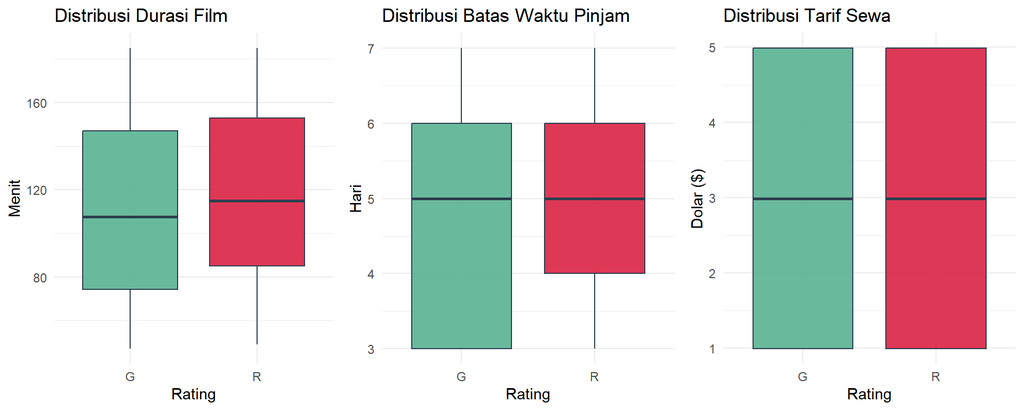

```r
library(ggplot2)
library(gridExtra)

# Tema warna kustom: G =hijau, R = merah
warna_kustom <- c("R" = "#D92243", "G" = "#59B292")

# 1. Boxplot untuk Durasi Film (length)
p1 <- ggplot(film_data, aes(x = rating, y = length, fill = rating)) +
  geom_boxplot(alpha = 0.9, color = "#2c3e50") +
  scale_fill_manual(values = warna_kustom) +
  labs(title = "Distribusi Durasi Film", x = "Rating", y = "Menit") +
  theme_minimal() +
  theme(legend.position = "none")

# 2. Boxplot untuk Batas Waktu Peminjaman (rental_duration)
p2 <- ggplot(film_data, aes(x = rating, y = rental_duration, fill = rating)) +
  geom_boxplot(alpha = 0.9, color = "#2c3e50") +
  scale_fill_manual(values = warna_kustom) +
  labs(title = "Distribusi Batas Waktu Pinjam", x = "Rating", y = "Hari") +
  theme_minimal() +
  theme(legend.position = "none")

# 3. Boxplot untuk Tarif Sewa (rental_rate)
p3 <- ggplot(film_data, aes(x = rating, y = rental_rate, fill = rating)) +
  geom_boxplot(alpha = 0.9, color = "#2c3e50") +
  scale_fill_manual(values = warna_kustom) +
  labs(title = "Distribusi Tarif Sewa", x = "Rating", y = "Dolar ($)") +
  theme_minimal() +
  theme(legend.position = "none")

# Menampilkan ketiga grafik secara berdampingan jajar satu baris
grid.arrange(p1, p2, p3, ncol = 3)
```

Berdasarkan pengamatan bentuk visual pada ketiga grafik boxplot komparatif, berikut adalah fakta-fakta yang tertangkap pada masing-masing variabel:

### Visualisasi Multivariate (Facet Scatter Plot Gabungan)

Untuk melihat interaksi dan pola persebaran antara durasi film (`length`), batas waktu peminjaman (`rental_duration`), dan tarif sewa (`rental_rate`) secara simultan berdasarkan kelompok rating, berikut adalah sintaks visualisasinya:

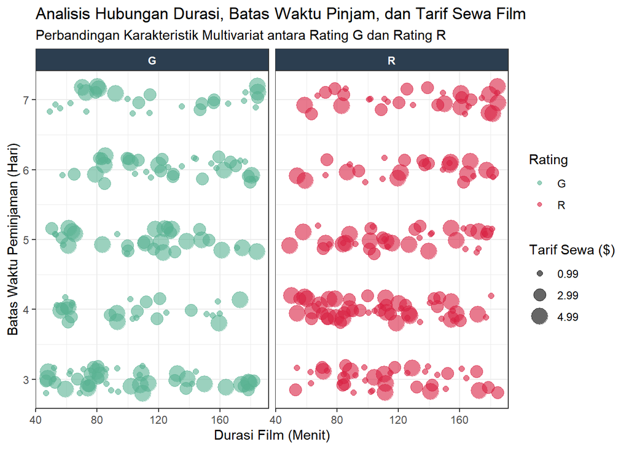

```r
library(ggplot2)

# Tema warna kustom sesuai estetika laporan kamu sebelumnya
warna_kustom <- c("R" = "#D92243", "G" = "#59B292")

# Membuat Scatter Plot Gabungan
ggplot(film_data, aes(x = length, y = rental_duration, color = rating)) +
  # geom_jitter digunakan agar titik-titik pada batas waktu (hari) tidak menumpuk kaku
  geom_jitter(aes(size = factor(rental_rate)), alpha = 0.6, width = 0.5, height = 0.2) +
  scale_color_manual(values = warna_kustom) +
  # Memisahkan panel grafik menjadi berdampingan berdasarkan Rating G dan R
  facet_wrap(~rating) +
  labs(
    title = "Analisis Hubungan Durasi, Batas Waktu Pinjam, dan Tarif Sewa Film",
    subtitle = "Perbandingan Karakteristik Multivariat antara Rating G dan Rating R",
    x = "Durasi Film (Menit)",
    y = "Batas Waktu Peminjaman (Hari)",
    size = "Tarif Sewa ($)",
    color = "Rating"
  ) +
  theme_bw() + # Menggunakan tema border putih-abu yang bersih
  theme(
    strip.background = element_rect(fill = "#2c3e50"), # Mengubah warna header kotak facet
    strip.text = element_text(color = "white", face = "bold"),
    legend.position = "right"
  )
```

Sebelum masuk ke analisis tren bisnis, berikut adalah cara membaca elemen visual yang ada pada grafik:

- Sumbu Horizontal (Sumbu-X): Menunjukkan Durasi Film (dalam satuan menit). Semakin ke kanan posisi titik bulatnya, maka durasi tayang film tersebut semakin panjang.
- Sumbu Vertikal (Sumbu-Y): Menunjukkan kebijakan Batas Waktu Peminjaman (dalam satuan hari), berkisar di angka bulat 3 hingga 7 hari.
- Ukuran Gelembung Titik (Size): Menunjukkan Tarif Sewa Film. Semakin besar diameter lingkaran titiknya, semakin mahal harga sewanya ($4.99). Sebaliknya, semakin kecil titiknya, harganya semakin murah ($0.99).
- Pembagian Panel Grafik (Facet Wrap): Data dipisahkan secara berdampingan untuk mempermudah komparasi, yaitu panel sebelah kiri untuk Rating G (keluarga/semua umur) dan panel sebelah kanan untuk Rating R (dewasa).

Berdasarkan pengamatan langsung terhadap sebaran titik-titik pada grafik multivariate facet scatter plot, berikut adalah fakta-fakta mentah yang ditemukan:

**A. Persebaran Ukuran Titik (Variabel rental_rate)**

Kondisi Visual: Lingkaran berukuran besar ($4.99), sedang ($2.99), dan kecil ($0.99) tersebar secara acak dan bercampur di seluruh area grafik. Tidak ditemukan adanya pengelompokan khusus di mana titik besar hanya menumpuk di area tertentu (misalnya di area durasi panjang saja). Pola ini terlihat sama persis, baik pada kotak panel Rating G (sebelah kiri) maupun kotak panel Rating R (sebelah kanan).

**B. Pola Barisan Lajur Vertikal (Variabel rental_duration)**

Kondisi Visual: Titik-titik data pada grafik tidak menyebar bebas secara vertikal ke atas atau ke bawah. Seluruh titik terkunci dan berbaris rapi membentuk lima lajur horizontal lurus tepat pada koordinat angka bulat, yaitu hari ke-3, 4, 5, 6, dan 7. Kerapatan barisan lima jalur ini terlihat sama kuat dan kembar di antara kedua panel rating.